# **第三章: 关联方法与关联矩阵**

本章内容简介：

- 3.1 目的
- 3.2 主要关联方法简介
- 3.3 Q Mode: 计算记录间的相异度矩阵
- 3.4 R Mode: 计算变量间的相关性
- 3.5 物种数据的预转换
- 3.6 结论

## 3.1 目的

在很多多元变量分析（尤其是排序和聚类分析）中，基于每条记录或者每个变量间的所有可能的分析成对的比较结果或是确定的、或是含糊的。 关联测度之间的比较（关联系数或者关联指数）通常是平方对称的关联矩阵，比如 n 个记录之间构成的 n * n 的二维矩阵， p 个变量之间构成的 p * P 的二维矩阵。 后续的所有相关分析都是基于关联矩阵进行的，因此选择合适的度量方式异常重要。 通过本章的学习，基本掌握：

- 初步掌握关联系数的主要类别；
- 掌握如何计算、测试、可视化相异矩阵（Q mode）和相关性矩阵（R mode）；
- 使用经典数据集进行应用；
- 进一步熟悉 R 语言的基本程序函数

## 3.2 主要关联方法简介

详细解释各种参数指标非本书的初衷，但重点介绍主要的分析类别则尤为重要。 选择合适的方式，利于后续的分析。

### 3.2.1 两种模式：Q Mode 与 R Mode

- Q Mode - 每条记录（对象）之间的两两比较: 主要分析相异矩阵或者相似矩阵
- R Mode - 每个变量（描述）之间的两两比较：主要分析变量之间的依赖性（相关性系数或者协方差）

### 3.2.2 Q Mode中的对称和非对称系数: Double-Zero 问题

实际上，生态学中使用的所有相异或相似性测度在一个意义上是对称的：n1和n2之间的系数值与n2和n1之间的系数值相同。 R mode中的情况类同。 本小节所讨论的问题则不同，主要涉及对象成对比较分析中的 Double-Zero 问题。

在某些案例中，零值和其他的数值一样都具有意义。 比如湖泊深层的无溶解氧的描述（0 mg/L）是就具有生物学意义的：浓度低于测量阈值对于有氧生命都是一种限制。

因此，“存在”信息比“缺失”信息具有更清晰的可解释性。 可以根据这个问题来区分两类关联测度：认为双零（有时亦称“负匹配”）是相似性指数的情况时，相关系数是对称的，反之则不是对称的。 除非有充分的证据证明两个地点都没有的物种是由于同一种原因引起的，否则分析物种数据时最好使用不对称类型的系数，这适用于所有的双零情况。 该场景最合适的示例是：已知群落组成的对照实验、或者具有干扰带地区的生物均一性。

### 3.2.3 定性或定量数据之间的关联度量

有些变量是定性变量（类别变量，二进制类型或者多类别），其他的是半定量（排序 - 序数）或者定量变量（离散值或者连续值）。 所有类型的变量都可以存在相关系数，但是可以主要分为两大类群，二元类型变量的系数（以下可简称“二进制系数”，虽然是二元变量，但不是关联测度的数值）和定量变量的系数（成为定量系数）。

### 3.2.4 小结…

在确定需要什么类型的关联度量进行分析之前，需要先理清一下几个问题：

- 比较对象（Q mode）还是比较变量（R mode）？
- 是处理非对称系数（比如物种数量）还是处理其他类型的变量（对称系数）？
- 数据类型是二元数据（或者说是二进制类型数据）、定量类型的数据还是混合型数据、还是其他类型的数据（比如序数、某些特殊系数等）？

以下内容将探索分析各种可能性，同时在大多数情况下，使用多种关联度量来研究给定问题。

## 3.3 Q Mode: 计算不同对象间的相异度矩阵

在该部分的分析过程中使用的 R 分析包是 stats, vegan, ade4, adespatial, cluster 和 FD。 以上列举的分析包基本能满足多数生态学研究的要求。 **在 R 中通常将相似性度量转换成相异性度量来计算平方矩阵（ n * n ）。**不同的 R 分析包中对相异矩阵的计算方法或者过程有所不同，因此如果要彻底地理清不同的相异矩阵的计算过程，需要回归到各自相应的 R 分析包。

### 3.3.1 Q Mode: 定量物种数据

分析的数据集是 Doubs 河流数据集中的 spe 数据，该数据并不是严格意义上的定量数据（但视其为定量数据），数据集中的数值并不比代表原始的鱼类丰度信息。

定量物种数据通常需要非对称的相异测度，在这一类别的分析中常用百分比差并计算各种不同相异度；本部分的分析过程中使用 gclus 进行可视化。

- **Percentage difference (aka Bray-Curtis)** 相异矩阵可以直接通过原始数据计算获得，虽然期间真实的丰度数值会经过 对数变换，该方法非常重视相互之间的**绝对差异**，虽然有时不同数据集之间相差较大的数量级（比如 3 与 8， 6203 与 6208）
- **chord distance** 是一种 Euclidean distance，通过将位点向量标准化至长度为 1 之后计算获得，这种标准化过程称之为“弦变换”
- **Hellinger distance** 也是一种 Euclidean distance，位点向量之间的距离，丰度值首先除以位点的总丰度值，其结果是平方根变换的，因此也称 “Hellinger变换”
- **log-chord distance** 是一种应用于对数转换的丰度数据的弦距离

```r
# 解决警告信息的显示问题
# Warning: Input string not available in this locale
Sys.setlocale('LC_ALL','C')
```

```
## [1] "C"
```

```r
# 导入所需要的 R 分析包
library(ade4)
library(adespatial)
library(vegan)
library(gclus)
library(cluster)
library(FD)
# 注意所需要的分析脚本和原数据的路径 与 已设置的工作路劲
# https://github.com/CMET-UGent/CMETNGS/tree/master/R
source("Functions/coldiss.R") # 调用分析脚本文件
source("Functions/panelutils.R") # 调用分析脚本文件

load("Data/Doubs.Rdata") # 导入处于工作路径中的 Doubs 河流数据集

spe <- spe[-8, ] # 删除第 8 行（位点）
dim(spe) #查看数据维度（行，列）
```

```
## [1] 29 27
```

```r
env <- env[-8, ] # 删除第 8 行（位点）
dim(env) #查看数据维度（行，列）
```

```
## [1] 29 11
```

```r
spa <- spa[-8, ] # 删除第 8 行（位点）
dim(spa) #查看数据维度（行，列）
```

```
## [1] 29  2
```

```r
spe.db <- vegdist(spe)  # 相异矩阵，方法 - "bray" (默认)
head(spe.db) # 查看数据
```

```
## [1] 0.6000000 0.6842105 0.7500000 0.8918919 0.7500000 0.6842105
```

```r
spe.dbln <- vegdist(log1p(spe)) # 相异矩阵，方法 - "bray" (默认)； 数据变换
head(spe.dbln) # 查看数据
```

```
## [1] 0.5509095 0.6280761 0.7446012 0.8664653 0.7657643 0.6519273
```

```r
# 一步弦距离矩阵计算
# dist.ldc 用于计算群落组成型数据的相异矩阵
spe.dc <- dist.ldc(spe, "chord") # "弦变换"相关的距离矩阵
```

```
## Info -- This coefficient is Euclidean
```

```r
# 两步组合弦距离计算
spe.norm <- decostand(spe, "nor") # 数据变换
spe.dc <- dist(spe.norm) # 采用默认方法("Euclidean")计算距离矩阵
head(spe.dc) # 查看数据
```

```
## [1] 0.7653669 0.9235374 1.0432236 1.2786132 1.1153793 0.8873116
```

```r
# 一步 Hellinger 距离矩阵计算
# dist.ldc 用于计算群落组成型数据的相异矩阵
spe.dh <- dist.ldc(spe) # 默认使用 Hellinger 距离方法计算
```

```
## Info -- This coefficient is Euclidean
```

```r
# 两步组合 Hellinger 距离计算
spe.hel <- decostand(spe, "hel") # 数据变换
spe.dh <- dist(spe.hel) # 采用默认方法("Euclidean")计算距离矩阵
head(spe.dh) # 查看数据
```

```
## [1] 0.8420247 0.9391305 1.0616631 1.2308244 1.1153793 0.9391305
```

```r
# 一步 Log-chord 距离矩阵计算
# dist.ldc 用于计算群落组成型数据的相异矩阵
spe.logchord <- dist.ldc(spe, "log.chord")
```

```
## Info -- This coefficient is Euclidean
```

```r
# 两步组合 Log-chord 距离计算
spe.ln <- log1p(spe)
spe.ln.norm <- decostand(spe.ln, "nor")
spe.logchord <- dist(spe.ln.norm)  # 采用默认方法("Euclidean")计算距离矩阵
head(spe.logchord) # 查看数据
```

```
## [1] 0.8428953 0.9343800 1.0500570 1.2352777 1.1031789 0.9301624
```

> ?? 为什么使用 **log1p** 而不是 **log** ??

### 3.3.2 Q Mode: Binary (Presence-Absence) Species Data

当唯一可用的数据是二元型数据、或者与丰度无关、或者包含不相等/不确定的数值时，都可进行将其转换成‘有-无’数据（1-0）进行分析。

```r
# Jaccard 相异矩阵
spe.dj <- vegdist(spe, "jac", binary = TRUE) # binary 数据转换为 "有-无"二进类型
head(spe.dj) #查看数据
```

```
## [1] 0.6666667 0.7500000 0.8750000 0.9090909 0.9000000 0.8000000
```

```r
head(sqrt(spe.dj)) #查看数据
```

```
## [1] 0.8164966 0.8660254 0.9354143 0.9534626 0.9486833 0.8944272
```

```r
# 两步组合 Jaccard 相异矩阵
spe.dj2 <- dist(spe, "binary")
spe.dj3 <- dist.binary(spe, method = 1) # 依据不同的方法将数据转换成"有-无"二进制类型
head(spe.dj3) #查看数据
```

```
## [1] 0.8164966 0.8660254 0.9354143 0.9534626 0.9486833 0.8944272
```

```r
# dist.ldc 用于计算群落组成型数据的相异矩阵
spe.ds <- dist.ldc(spe, "sorensen") # Sorensen 相异矩阵
```

```
## Info -- D is Euclidean because the function outputs D[jk] = sqrt(1-S[jk])
```

```r
spe.ds2 <- vegdist(spe, method = "bray", binary = TRUE) # bray 相异矩阵 | "有-无"二进类型
spe.ds3 <- dist.binary(spe, method = 5) # 依据不同的方法将数据转换成"有-无"二进制类型
head(spe.ds) # dist.ldc(spe, "sorensen")
```

```
## [1] 0.7071068 0.7745967 0.8819171 0.9128709 0.9045340 0.8164966
```

```r
head(spe.ds2) # vegdist(spe, method = "bray", binary = TRUE) # bray 相异矩阵 | "有-无"二进类型
```

```
## [1] 0.5000000 0.6000000 0.7777778 0.8333333 0.8181818 0.6666667
```

```r
head(sqrt(spe.ds2)) # vegdist(spe, method = "bray", binary = TRUE)
```

```
## [1] 0.7071068 0.7745967 0.8819171 0.9128709 0.9045340 0.8164966
```

```r
head(spe.ds3) #  dist.binary(spe, method = 5)
```

```
## [1] 0.7071068 0.7745967 0.8819171 0.9128709 0.9045340 0.8164966
```

```r
# 两步组合 Ochiai 相异矩阵
# dist.ldc 用于计算群落组成型数据的相异矩阵
spe.och <- dist.ldc(spe, "ochiai")
```

```
## Info -- D is Euclidean because the function outputs D[jk] = sqrt(1-S[jk])
```

```r
spe.och <- dist.binary(spe, method = 7)  # 依据不同的方法将数据转换成"有-无"二进制类型
head(spe.och) #查看数据
```

```
## [1] 0.6501152 0.7071068 0.8040190 0.8357563 0.8269052 0.7434961
```

> 没有必要对数据进行初步的二元数据变换

对涉及较多对象的关联矩阵进行可视化以方便研究。

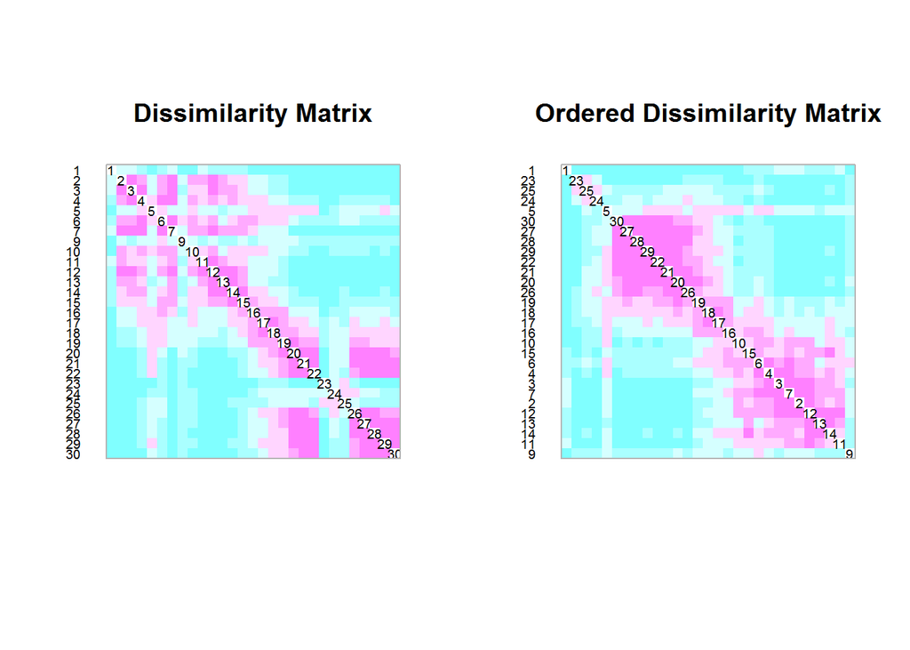

```r
# 可视化关联矩阵/相异矩阵
# https://github.com/CMET-UGent/CMETNGS/tree/master/R
# coldiss(D, nc = 4, byrank = TRUE, diag = FALSE)
# D- 相异矩阵；nc - 颜色数量, 默认为 4 ；
# byrank - 指定任意大小的类 (TRUE - 默认)； 等长间隔 (FALSE)
# diag - 在对角线上打印对象标签 (FALSE)
coldiss(spe.db, 6, byrank = FALSE, diag = T) # 原始物种丰度数据
```

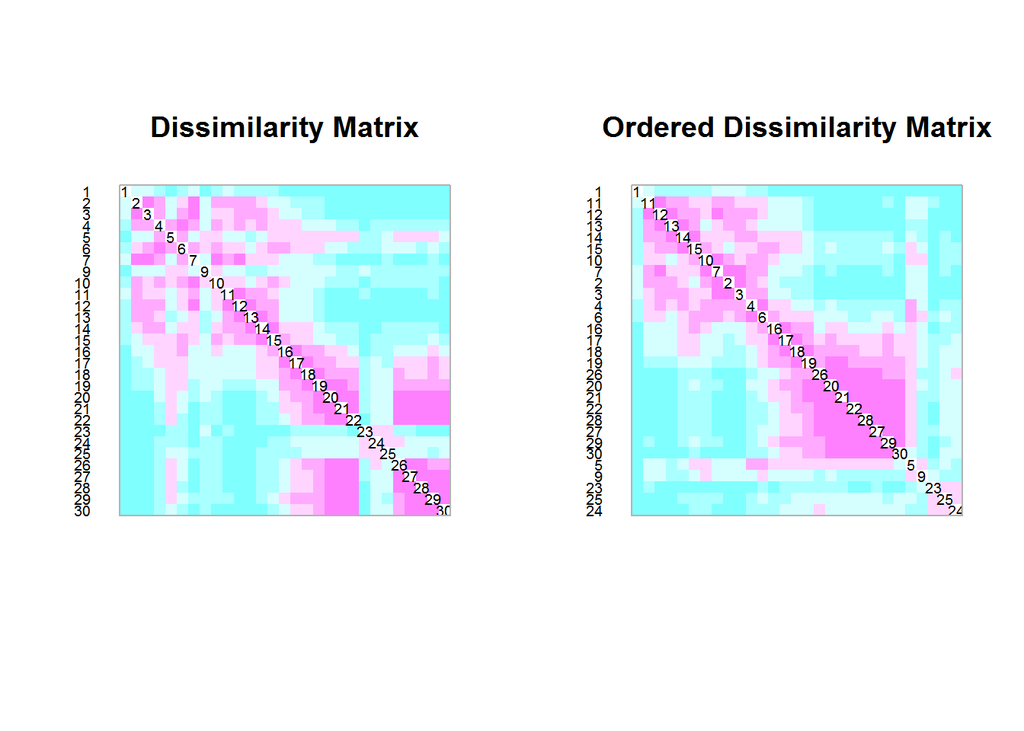

```r
# 在未进行数据变换的相异矩阵中，丰富物种之间的小差异 与 个体数量较少的物种之间的小差异 具有相同重要的意义
coldiss(spe.dbln, 6, byrank = FALSE, diag = T) # log 变换数据
```

[figure not shown]

```r
coldiss(spe.dc, 6, byrank = FALSE, diag = T) # 弦距离矩阵
```

[figure not shown]

```r
coldiss(spe.dh, 6, byrank = FALSE, diag = T) # Hellinger 距离矩阵
```

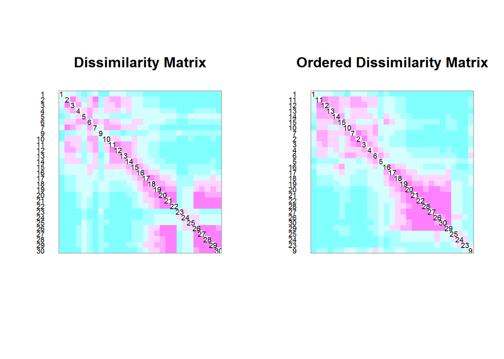

```r
coldiss(spe.logchord, 6, byrank = FALSE, diag = T) # log-chord 距离矩阵
```

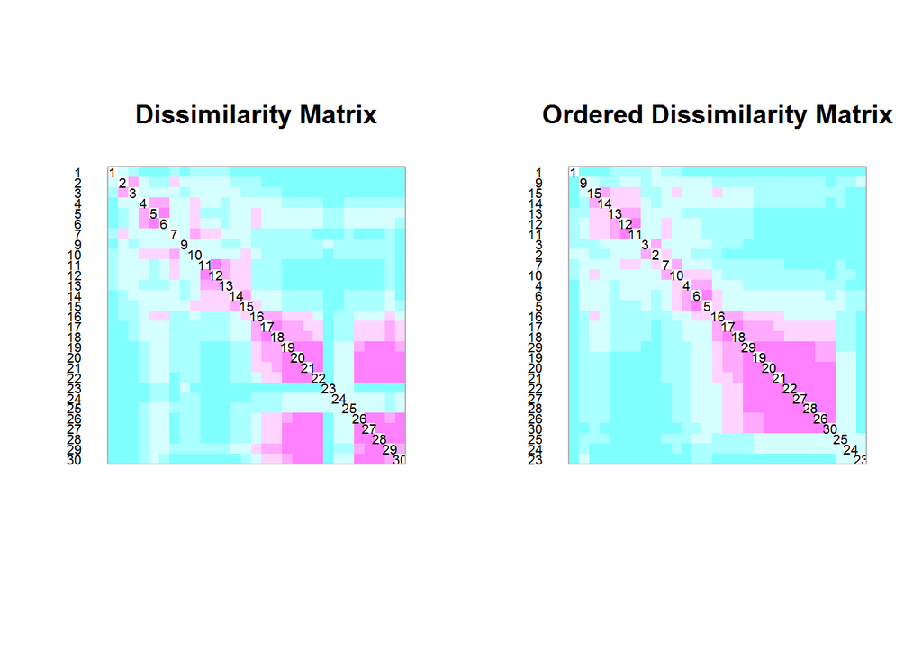

```r
coldiss(spe.dj, 6, byrank = FALSE, diag = T) # Jaccard 距离矩阵
```

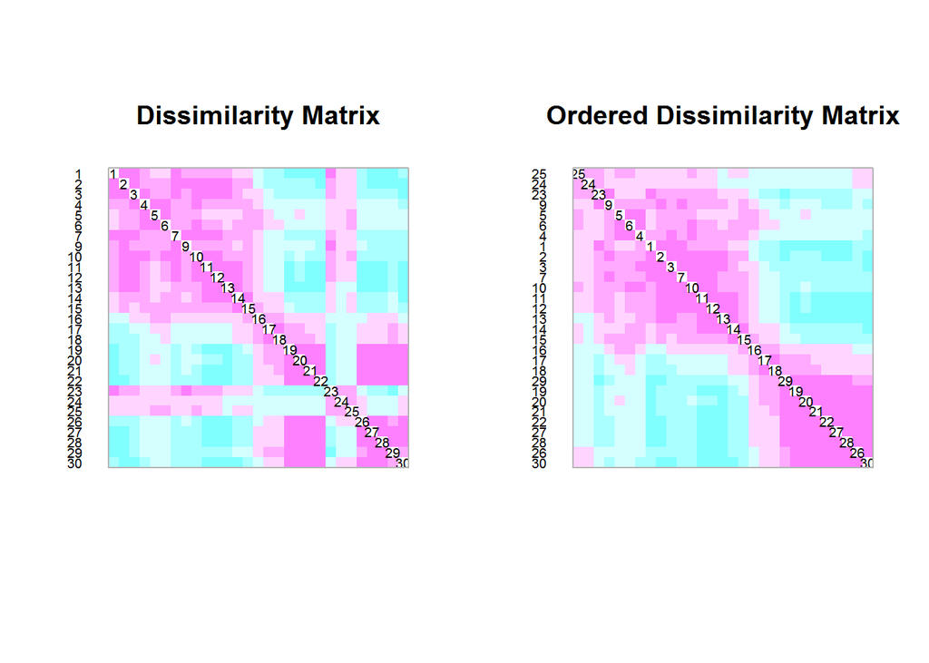

```r
# Simple matching coefficient of Sokal & Michener
spe.s1 <- dist.binary(spe, method = 2) # method = 2 决定了使用的方法
coldiss(spe.s1 ^ 2, 6, byrank = FALSE, diag = T)
```

> 比较 **Jaccard 矩阵**与其他的**对称性相异矩阵**的差异，在应对**双零**问题（Double zeros）时，哪种相异矩阵最受影响？

### 3.3.3 Q Mode: Quantitative Data (不包括 Species Abundances)

对于对双零数据具有明确解释的定量数据来说，最佳的对称性距离度量方法是 Euclidean distance。 欧氏距离在使用上没有什么上限，其值受每个变量尺度的强烈影响（比如改变测量的统计单位，会影响欧式距离的贡献程度），因此对原始数据使用欧氏距离进行的分析仅仅限于相同维度同质化的数据集（比如地理坐标）。 标准化之后赋予同一维度相同的变量权重之后亦可继续分析。

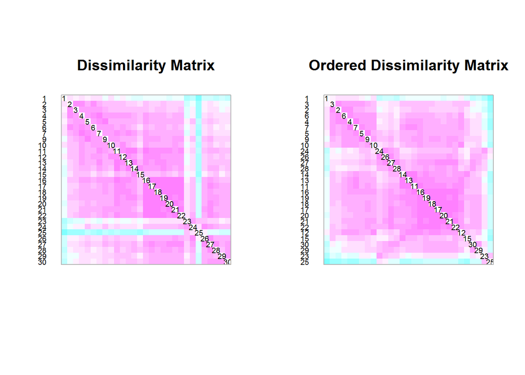

```r
env2 <- env[, -1] # 删除第 1 列
# 查看帮助系统，进一步了解 scale() 的用法
env.de <- dist(scale(env2)) # 数据变换之后， 采用默认方法("Euclidean")计算距离矩阵
coldiss(env.de, nc = 16, byrank = FALSE, diag = TRUE)
```

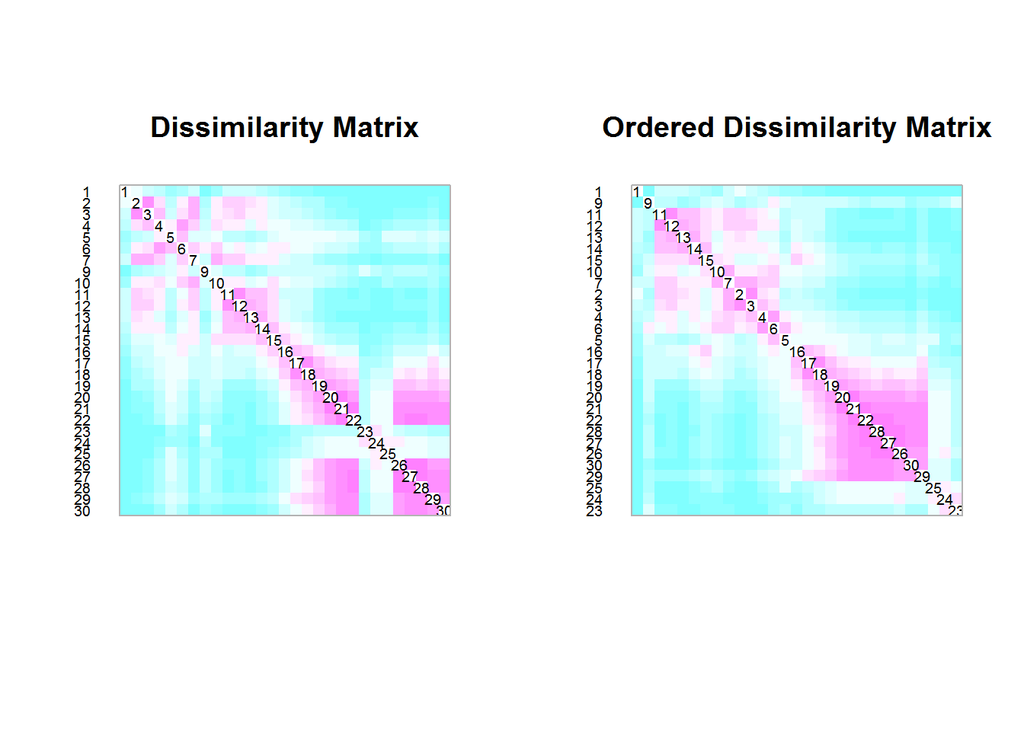

```r
# 注意不同数据变换之后的比较；注意呈现的不同顺序
coldiss(spe.dh, nc = 16,byrank = FALSE, diag = TRUE)# spe.dh -- Hellinger 距离矩阵
```

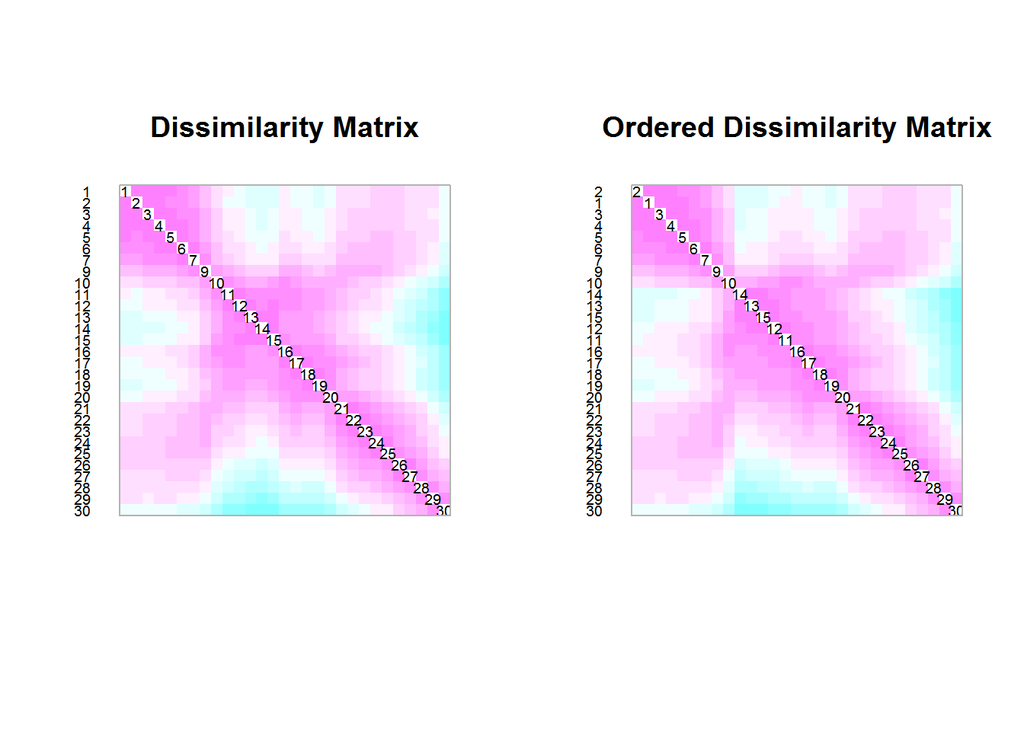

```r
# Euclidean 距离方法非常适合地理数据的矩阵分析
spa.de <- dist(spa) # 使用默认 Euclidean 距离方法作相异距离矩阵 | 空间信息
coldiss(spa.de, nc = 16, byrank = F, diag = TRUE) # 可视化相异矩阵
```

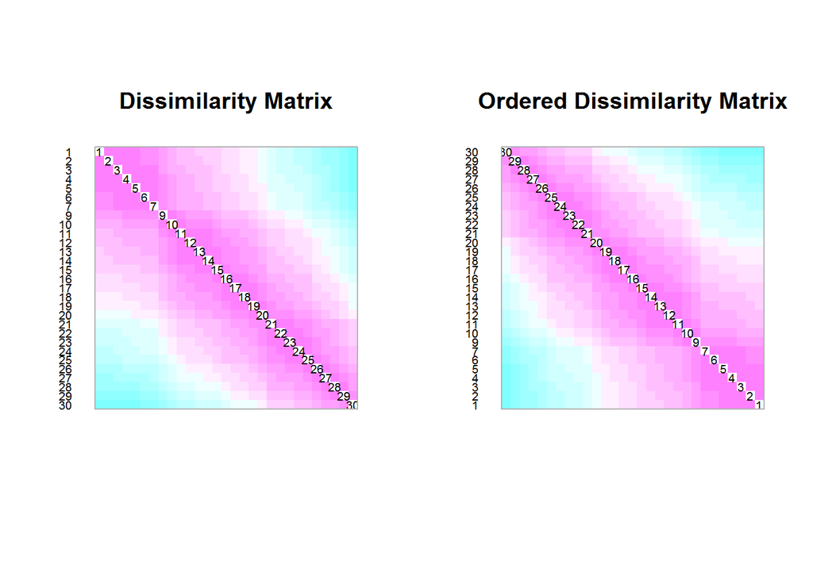

```r
dfs.df <- as.data.frame(env$dfs, row.names = rownames(env))
riv.de <- dist(dfs.df) # 使用默认 Euclidean 距离方法作相异距离矩阵
coldiss(riv.de, nc = 16, byrank = F, diag = TRUE) # 可视化相异矩阵
```

> 思考：为什么 X-Y 图和Euclidean距离图不一样？

### 3.3.4 Q Mode: Binary Data (除了 Species Presence-Absence Data)

对于二元数据来说，最简单的对称性相似度量方法是“Simple matching coefficient”，对于位点的每对比较，该值是双 1 数量和双 0 数量与总变量数的比值。

```r
rep(1, 10)
```

```
##  [1] 1 1 1 1 1 1 1 1 1 1
```

```r
rep(0, 20)
```

```
##  [1] 0 0 0 0 0 0 0 0 0 0 0 0 0 0 0 0 0 0 0 0
```

```r
c(rep(1, 10), rep(0, 20))
```

```
##  [1] 1 1 1 1 1 1 1 1 1 1 0 0 0 0 0 0 0 0 0 0 0 0 0 0 0 0 0 0 0 0
```

```r
var1 <- sample(c(rep(1, 10), rep(0, 20))) # 随机顺序排列
var2 <- c(rep(0, 15), rep(1, 15))
rep(c(1, 0), 5)
```

```
##  [1] 1 0 1 0 1 0 1 0 1 0
```

```r
var3 <- rep(c(1, 1, 1, 0, 0, 0), 5)
var4 <- rep(c(rep(1, 5), rep(0, 10)), 2)
var5.1 <- sample(c(rep(1, 7), rep(0, 9)))
var5.2 <- c(rep(0, 4), rep(1, 10))
var5 <- c(var5.1, var5.2)
dat <- data.frame(var1, var2, var3, var4, var5) # 创建数据框
dim(dat) # 查看数据维度
```

```
## [1] 30  5
```

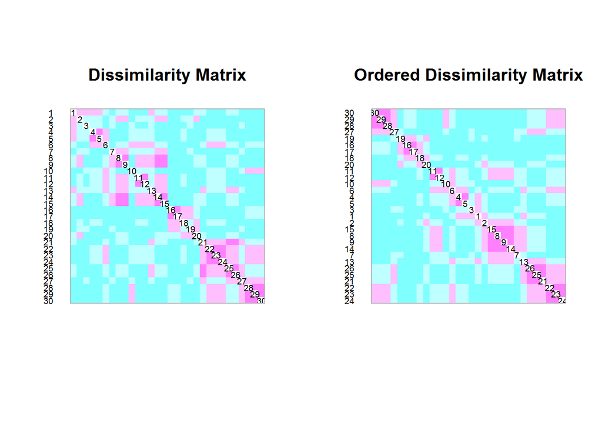

```r
dat.s1 <- dist.binary(dat, method = 2) # Simple matching coefficient
coldiss(dat.s1, byrank = F, diag = TRUE) # 可视化相异矩阵
```

### 3.3.5 Q Mode: Mixed Types Including Categorical(Qualitative Multiclass) Variables

在 R 中可以借助 Gower’s similarity 的关联度量正确地处理‘名称性数据’，可以使用该系数处理包含各种数学类型变量的数据（**混合类型数据**），每个变量都会得到相应的分析处理。 通过分别平均化所有变量的部分相异/相似性数值，最终获得两个对象的相异/相似系数。

```r
var.g1 <- rnorm(30, 0, 1) # 随机正态分布 - 均值 0，标准差 1
var.g2 <- runif(30, 0, 5) # 随机正态分布 - 均值 0，标准差 5
gl(3, 10) # （1，2，3）3 个数，每个重复 10 遍 | 主要用于进一步生成因子向量
```

```
##  [1] 1 1 1 1 1 1 1 1 1 1 2 2 2 2 2 2 2 2 2 2 3 3 3 3 3 3 3 3 3 3
## Levels: 1 2 3
```

```r
var.g3 <- gl(3, 10, labels = c("A", "B", "C")) # 创建因子向量
var.g3
```

```
##  [1] A A A A A A A A A A B B B B B B B B B B C C C C C C C C C C
## Levels: A B C
```

```r
gl(2, 5, 30) # （1，2）2 个数，每个重复 5 遍，一共 30 个数
```

```
##  [1] 1 1 1 1 1 2 2 2 2 2 1 1 1 1 1 2 2 2 2 2 1 1 1 1 1 2 2 2 2 2
## Levels: 1 2
```

```r
var.g4 <- gl(2, 5, 30, labels = c("D", "E")) # 创建因子向量
var.g4
```

```
##  [1] D D D D D E E E E E D D D D D E E E E E D D D D D E E E E E
## Levels: D E
```

```r
#  var.g3 和 var.g4 代表了‘双向交叉平衡设计’
dat2 <- data.frame(var.g1, var.g2, var.g3, var.g4)
dim(dat2) # 查看数据维度
```

```
## [1] 30  4
```

```r
summary(dat2) # 统计每列的基本信息
```

```
##      var.g1             var.g2        var.g3 var.g4
##  Min.   :-1.76993   Min.   :0.08667   A:10   D:15
##  1st Qu.:-0.50367   1st Qu.:1.39612   B:10   E:15
##  Median :-0.03066   Median :2.80950   C:10
##  Mean   :-0.01427   Mean   :2.70092
##  3rd Qu.: 0.48705   3rd Qu.:4.05277
##  Max.   : 1.54048   Max.   :4.72234
```

```r
dat2.S15 <- daisy(dat2, "gower") # 计算数据集中观察值之间的所有成对差异（距离）| 测度方法 - Gower's distance
range(dat2.S15) # 查看数据的变化范围
```

```
## [1] 0.01122548 0.84375103
```

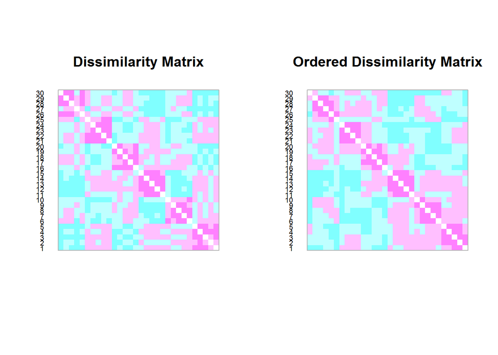

```r
coldiss(dat2.S15, byrank = F, diag = T) # 可视化相异矩阵
```

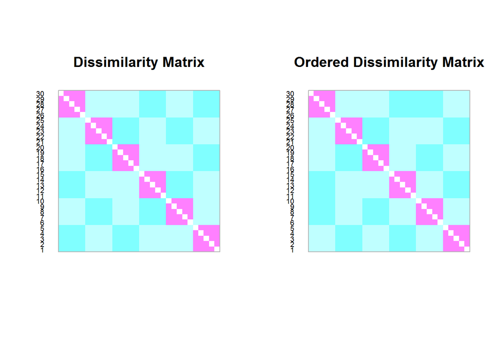

```r
dat2partial.S15 <- daisy(dat2[, 3:4], "gower") # 只计算两个正交因子的距离（差异）
coldiss(dat2partial.S15, byrank = F, diag = T) # 可视化相异矩阵
```

```r
head(as.matrix(dat2partial.S15)) # 查看数据头部
```

```
##     1   2   3   4   5   6   7   8   9  10  11  12  13  14  15  16  17  18
## 1 0.0 0.0 0.0 0.0 0.0 0.5 0.5 0.5 0.5 0.5 0.5 0.5 0.5 0.5 0.5 1.0 1.0 1.0
## 2 0.0 0.0 0.0 0.0 0.0 0.5 0.5 0.5 0.5 0.5 0.5 0.5 0.5 0.5 0.5 1.0 1.0 1.0
## 3 0.0 0.0 0.0 0.0 0.0 0.5 0.5 0.5 0.5 0.5 0.5 0.5 0.5 0.5 0.5 1.0 1.0 1.0
## 4 0.0 0.0 0.0 0.0 0.0 0.5 0.5 0.5 0.5 0.5 0.5 0.5 0.5 0.5 0.5 1.0 1.0 1.0
## 5 0.0 0.0 0.0 0.0 0.0 0.5 0.5 0.5 0.5 0.5 0.5 0.5 0.5 0.5 0.5 1.0 1.0 1.0
## 6 0.5 0.5 0.5 0.5 0.5 0.0 0.0 0.0 0.0 0.0 1.0 1.0 1.0 1.0 1.0 0.5 0.5 0.5
##    19  20  21  22  23  24  25  26  27  28  29  30
## 1 1.0 1.0 0.5 0.5 0.5 0.5 0.5 1.0 1.0 1.0 1.0 1.0
## 2 1.0 1.0 0.5 0.5 0.5 0.5 0.5 1.0 1.0 1.0 1.0 1.0
## 3 1.0 1.0 0.5 0.5 0.5 0.5 0.5 1.0 1.0 1.0 1.0 1.0
## 4 1.0 1.0 0.5 0.5 0.5 0.5 0.5 1.0 1.0 1.0 1.0 1.0
## 5 1.0 1.0 0.5 0.5 0.5 0.5 0.5 1.0 1.0 1.0 1.0 1.0
## 6 0.5 0.5 1.0 1.0 1.0 1.0 1.0 0.5 0.5 0.5 0.5 0.5
```

```r
levels(factor(dat2partial.S15)) # 查看相异矩阵中不同值
```

```
## [1] "0"   "0.5" "1"
```

```r
dat2.S15.2 <- gowdis(dat2) # 计算 Gower 相异度矩阵
range(dat2.S15.2) # 查看数据的变化范围
```

```
## [1] 0.01122548 0.84375103
```

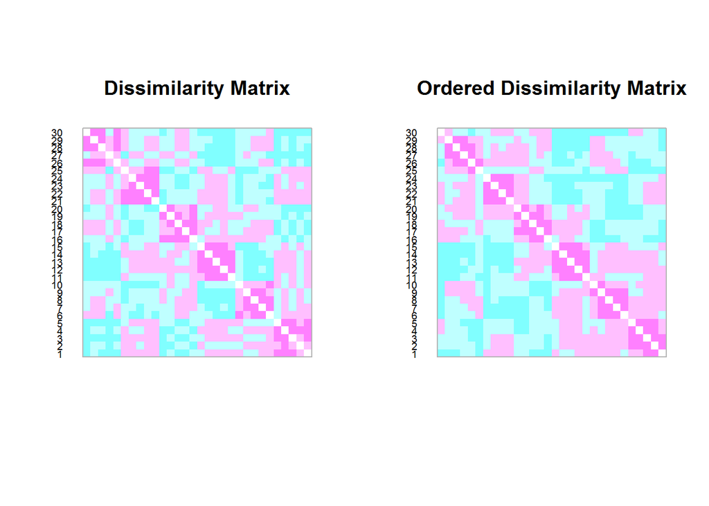

```r
coldiss(dat2.S15.2, byrank = F, diag = T) # 可视化相异矩阵
```

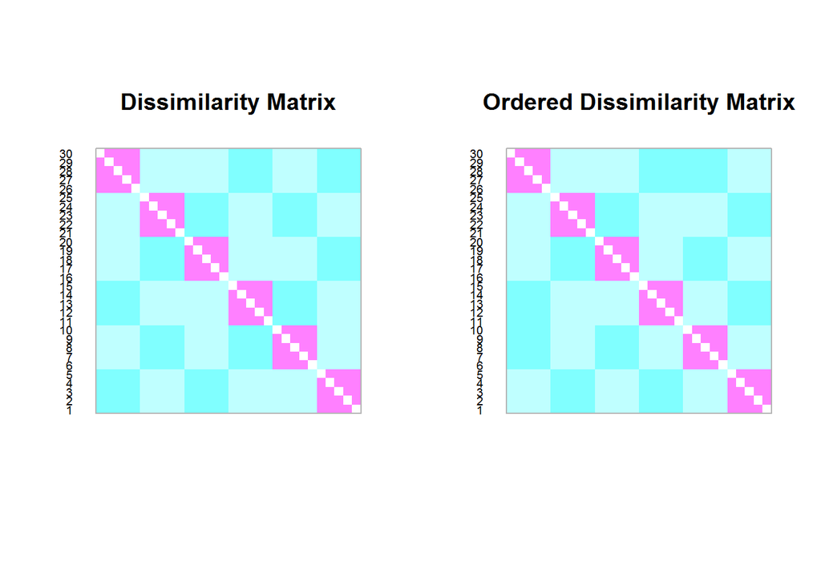

```r
dat2partial.S15.2 <- gowdis(dat2[, 3:4]) # 计算两个正交因子的 Gower 相异度矩阵
coldiss(dat2partial.S15.2, byrank = F, diag = T) # 可视化相异矩阵
```

```r
head(as.matrix(dat2partial.S15.2)) # 查看数据
```

```
##     1   2   3   4   5   6   7   8   9  10  11  12  13  14  15  16  17  18
## 1 0.0 0.0 0.0 0.0 0.0 0.5 0.5 0.5 0.5 0.5 0.5 0.5 0.5 0.5 0.5 1.0 1.0 1.0
## 2 0.0 0.0 0.0 0.0 0.0 0.5 0.5 0.5 0.5 0.5 0.5 0.5 0.5 0.5 0.5 1.0 1.0 1.0
## 3 0.0 0.0 0.0 0.0 0.0 0.5 0.5 0.5 0.5 0.5 0.5 0.5 0.5 0.5 0.5 1.0 1.0 1.0
## 4 0.0 0.0 0.0 0.0 0.0 0.5 0.5 0.5 0.5 0.5 0.5 0.5 0.5 0.5 0.5 1.0 1.0 1.0
## 5 0.0 0.0 0.0 0.0 0.0 0.5 0.5 0.5 0.5 0.5 0.5 0.5 0.5 0.5 0.5 1.0 1.0 1.0
## 6 0.5 0.5 0.5 0.5 0.5 0.0 0.0 0.0 0.0 0.0 1.0 1.0 1.0 1.0 1.0 0.5 0.5 0.5
##    19  20  21  22  23  24  25  26  27  28  29  30
## 1 1.0 1.0 0.5 0.5 0.5 0.5 0.5 1.0 1.0 1.0 1.0 1.0
## 2 1.0 1.0 0.5 0.5 0.5 0.5 0.5 1.0 1.0 1.0 1.0 1.0
## 3 1.0 1.0 0.5 0.5 0.5 0.5 0.5 1.0 1.0 1.0 1.0 1.0
## 4 1.0 1.0 0.5 0.5 0.5 0.5 0.5 1.0 1.0 1.0 1.0 1.0
## 5 1.0 1.0 0.5 0.5 0.5 0.5 0.5 1.0 1.0 1.0 1.0 1.0
## 6 0.5 0.5 1.0 1.0 1.0 1.0 1.0 0.5 0.5 0.5 0.5 0.5
```

```r
levels(factor(dat2partial.S15.2)) # 查看相异矩阵中不同值
```

```
## [1] "0"   "0.5" "1"
```

## 3.4 R Mode: 计算变量间的相关性

使用相关型系数进行变量间的比较。 对定量型数据或序数型数据分析的非参相关系数有 Pearson、Spearman、Kendall。 对分类数据比较的偶然性统计的方法有 chi-square 及其派生形式。 对于‘有-无’数据，可以采用二元系数（Jaccard、Sørensen、Ochiai 系数）进行比较物种分析。

### 3.4.1 R Mode: Species Abundance Data

常采用协方差、有参相关系数、无参相关系数比较分析物种在时间或空间上的分布特点。 双零以及丰度的联合变化将会增加物种相关性。 除相关性外，原在 Q mode 中应用的 chi-square 距离方法也可在 R mode 中计算转置矩阵。

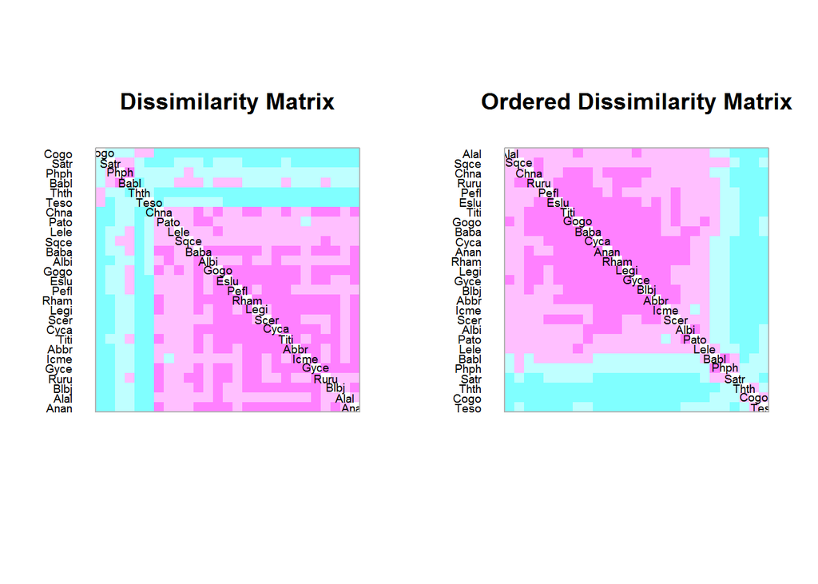

```r
spe.t <- t(spe) # 转置物种丰度矩阵数据
spe.t.chi <- decostand(spe.t, "chi.square") # 数据变换 | 卡方变换
spe.t.D16 <- dist(spe.t.chi) # 使用默认 Euclidean 方法计算距离矩阵
# 识别不同的物种
coldiss(spe.t.D16, byrank = F, diag = TRUE) # 可视化相异矩阵
```

### 3.4.2 R Mode: Species Presence-Absence Data

对于二元物种数据，Jaccard (S7), Sørensen (S8) and Ochiai (S14) 系数都可用在 R mode 中。

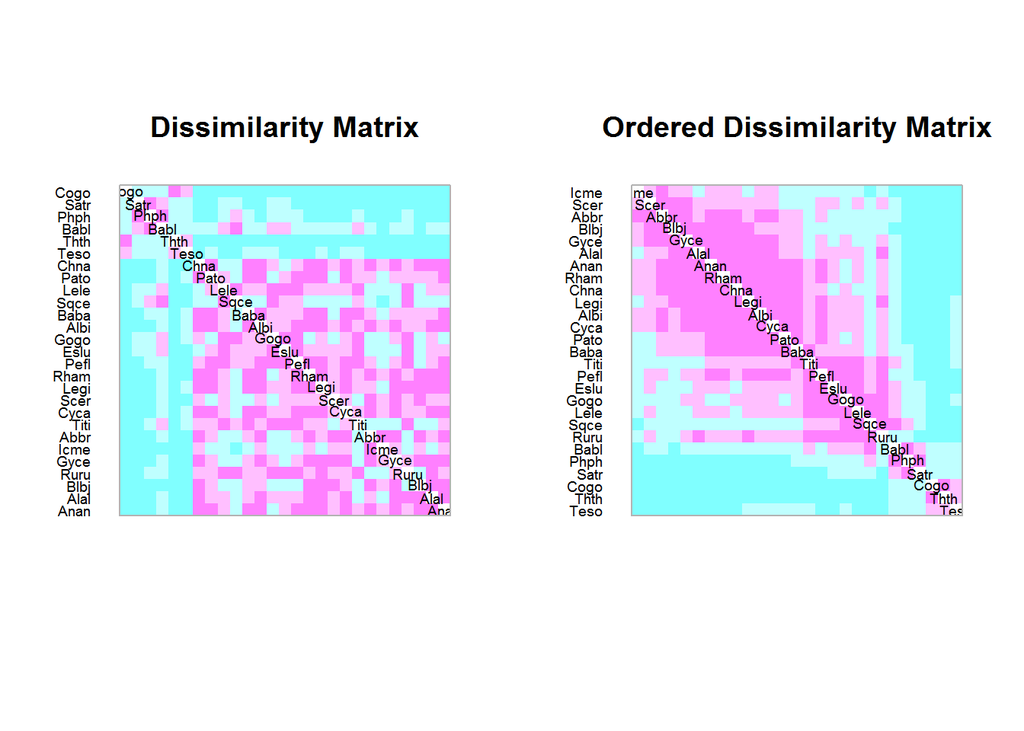

```r
spe.t.S7 <- vegdist(spe.t, "jaccard", binary = TRUE) # 鱼类丰度数据 | "有-无"二进制数据 | jaccard 距离矩阵
coldiss(spe.t.S7, diag = TRUE)# 可视化相异矩阵
```

### 3.4.3 R Mode: Quantitative and Ordinal Data (Other than Species Abundances)

如果变量再维度上表现非齐性（即维度非均质化），Pearson’s r 优于协方差的使用。系数 r 实际上是在标准化变量上计算的协方差。

```r
env.pearson <- cor(env) # 环境数据 | 使用默认 pearson 方法计算相关性
round(env.pearson, 2) # 保留两位小数
```

```
##       dfs   ele   slo   dis    pH   har   pho   nit   amm   oxy   bod
## dfs  1.00 -0.94 -0.39  0.95  0.02  0.73  0.47  0.74  0.41 -0.57  0.43
## ele -0.94  1.00  0.46 -0.86 -0.05 -0.79 -0.44 -0.75 -0.38  0.42 -0.38
## slo -0.39  0.46  1.00 -0.36 -0.22 -0.53 -0.20 -0.31 -0.17  0.31 -0.17
## dis  0.95 -0.86 -0.36  1.00  0.03  0.74  0.38  0.59  0.29 -0.42  0.30
## pH   0.02 -0.05 -0.22  0.03  1.00  0.08 -0.08 -0.04 -0.12  0.19 -0.16
## har  0.73 -0.79 -0.53  0.74  0.08  1.00  0.37  0.53  0.30 -0.37  0.34
## pho  0.47 -0.44 -0.20  0.38 -0.08  0.37  1.00  0.80  0.97 -0.76  0.91
## nit  0.74 -0.75 -0.31  0.59 -0.04  0.53  0.80  1.00  0.80 -0.69  0.68
## amm  0.41 -0.38 -0.17  0.29 -0.12  0.30  0.97  0.80  1.00 -0.75  0.90
## oxy -0.57  0.42  0.31 -0.42  0.19 -0.37 -0.76 -0.69 -0.75  1.00 -0.84
## bod  0.43 -0.38 -0.17  0.30 -0.16  0.34  0.91  0.68  0.90 -0.84  1.00
```

```r
head(env.pearson)
```

```
##             dfs         ele        slo         dis          pH         har
## dfs  1.00000000 -0.93837894 -0.3947527  0.94742121  0.01604625  0.73277932
## ele -0.93837894  1.00000000  0.4571298 -0.86289080 -0.05035674 -0.78551547
## slo -0.39475266  0.45712978  1.0000000 -0.35761430 -0.22222041 -0.52669175
## dis  0.94742121 -0.86289080 -0.3576143  1.00000000  0.03312637  0.73662526
## pH   0.01604625 -0.05035674 -0.2222204  0.03312637  1.00000000  0.08451511
## har  0.73277932 -0.78551547 -0.5266918  0.73662526  0.08451511  1.00000000
##            pho         nit        amm        oxy        bod
## dfs  0.4729141  0.73809569  0.4076923 -0.5700685  0.4346159
## ele -0.4371091 -0.75260515 -0.3811344  0.4248230 -0.3825222
## slo -0.1953638 -0.31433990 -0.1746442  0.3076363 -0.1738556
## dis  0.3786878  0.59315083  0.2925252 -0.4210945  0.2951891
## pH  -0.0794025 -0.04046292 -0.1220018  0.1923980 -0.1617056
## har  0.3731861  0.53495392  0.2961360 -0.3736374  0.3369747
```

```r
env.o <- order.single(env.pearson) # 使用分层聚类对对象进行排序
head(env.o)
```

```
## [1] 11  7  9  8  1  4
```

```r
# 绘制二元散点矩阵 - 数据集
head(env[, env.o])
```

```
##   bod  pho  amm  nit  dfs  dis har  pH  oxy ele  slo
## 1 2.7 0.01 0.00 0.20  0.3 0.84  45 7.9 12.2 934 48.0
## 2 1.9 0.02 0.10 0.20  2.2 1.00  40 8.0 10.3 932  3.0
## 3 3.5 0.05 0.05 0.22 10.2 1.80  52 8.3 10.5 914  3.7
## 4 1.3 0.10 0.00 0.21 18.5 2.53  72 8.0 11.0 854  3.2
## 5 6.2 0.38 0.20 0.52 21.5 2.64  84 8.1  8.0 849  2.3
## 6 5.3 0.20 0.00 0.15 32.4 2.86  60 7.9 10.2 846  3.2
```

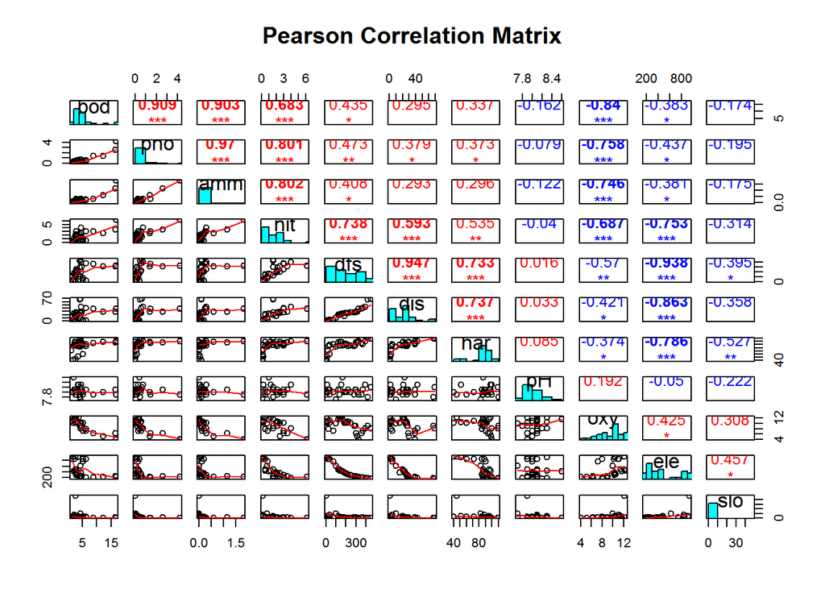

```r
# 绘制二元散点矩阵
pairs(env[, env.o],
  lower.panel = panel.smooth, # 左下角位置的绘图要求 - 绘制拟合曲线
  upper.panel = panel.cor, # 右上角位置的绘图要求 - 打印相关系数
  diag.panel = panel.hist, # 对角线位置的绘图要求 - 直方图
  main = "Pearson Correlation Matrix"
  )
```

```r
# 使用不同的方法计算相关性矩阵
env.ken <- cor(env, method = "kendall") # 环境数据 | 使用 kendall 方法计算相关性
head(env.ken)
```

```
##             dfs         ele         slo         dis          pH        har
## dfs  1.00000000 -1.00000000 -0.61808412  0.97536946  0.03268505  0.6000675
## ele -1.00000000  1.00000000  0.61808412 -0.97536946 -0.03268505 -0.6000675
## slo -0.61808412  0.61808412  1.00000000 -0.62312970 -0.09485373 -0.4814534
## dis  0.97536946 -0.97536946 -0.62312970  1.00000000  0.04902758  0.6050681
## pH   0.03268505 -0.03268505 -0.09485373  0.04902758  1.00000000  0.1410110
## har  0.60006751 -0.60006751 -0.48145340  0.60506807  0.14101101  1.0000000
##            pho         nit         amm        oxy        bod
## dfs  0.5665032  0.66007426  0.43865122 -0.3940456  0.3514895
## ele -0.5665032 -0.66007426 -0.43865122  0.3940456 -0.3514895
## slo -0.5879454 -0.55572015 -0.49771661  0.3499593 -0.3042375
## dis  0.5715165  0.63507145  0.41238468 -0.3691060  0.3514895
## pH   0.1413703  0.01105969 -0.05228407  0.1792655 -0.1177027
## har  0.4860067  0.46192893  0.30129798 -0.2607603  0.2763959
```

```r
env.o <- order.single(env.ken) # 使用分层聚类对对象进行排序
head(env.o)
```

```
## [1] 11  7  9  8  1  4
```

```r
head(env[, env.o])
```

```
##   bod  pho  amm  nit  dfs  dis har  pH  oxy ele  slo
## 1 2.7 0.01 0.00 0.20  0.3 0.84  45 7.9 12.2 934 48.0
## 2 1.9 0.02 0.10 0.20  2.2 1.00  40 8.0 10.3 932  3.0
## 3 3.5 0.05 0.05 0.22 10.2 1.80  52 8.3 10.5 914  3.7
## 4 1.3 0.10 0.00 0.21 18.5 2.53  72 8.0 11.0 854  3.2
## 5 6.2 0.38 0.20 0.52 21.5 2.64  84 8.1  8.0 849  2.3
## 6 5.3 0.20 0.00 0.15 32.4 2.86  60 7.9 10.2 846  3.2
```

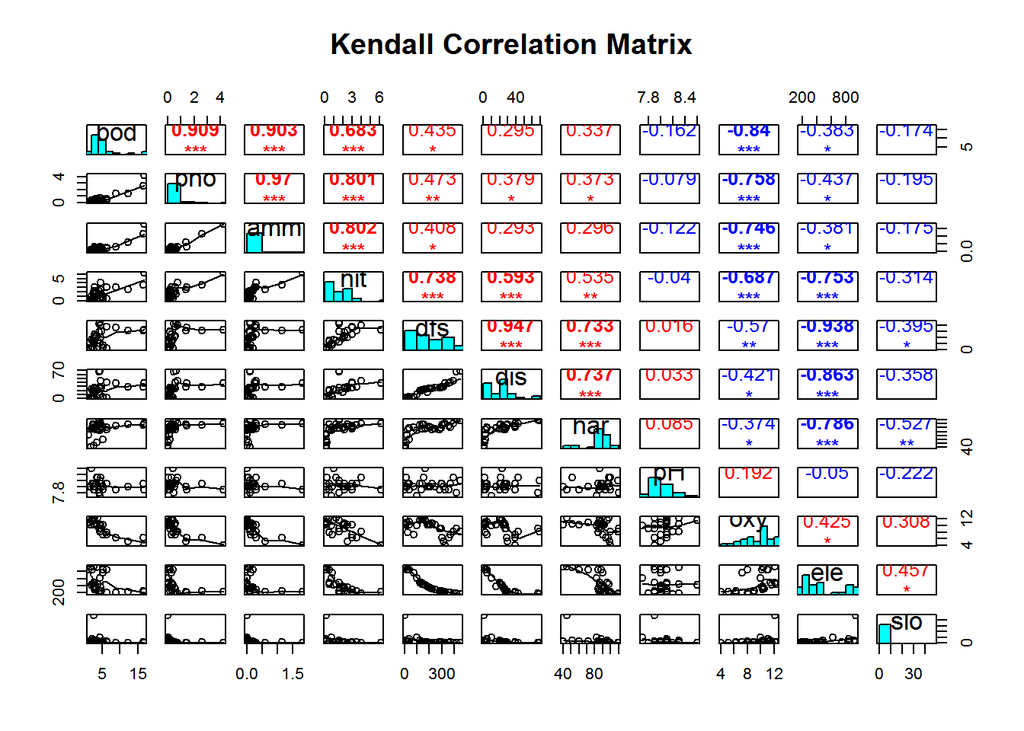

```r
pairs(env[, env.o], # 绘制二元散点矩阵
  lower.panel = panel.smoothb,  # 左下角位置的绘图要求 - 绘制拟合曲线
  upper.panel = panel.cor,  # 右上角位置的绘图要求 - 打印相关系数
  diag.panel = panel.hist, # 对角线位置的绘图要求 - 直方图
  main = "Kendall Correlation Matrix"
  )
```

> 通过二元散点图比较 kendall 与 pearson 两种方法！

### 3.4.4 R Mode: Binary Data (Other than Species Abundance Data)

比较二元变量对最简单的方法是计算 Pearson r 的相关性矩阵。

## 3.5 物种数据的预转换

物种数据的非对称的关联毒辣ing可以通过两步计算获得：转化原始数据，计算 Euclidean 距离。 以上可保证位点之间非对称的距离，因此可以使用线性分析方法（方差分析、k-均值分析、主成分分析-PCA、冗余分析-RDA）用于物种数据的分析。

Legendre 和 Gallagher提出过 5 种物种数据预转换的的方法，其中可以通过 vegan 分析包中的 decostand() 函数获得 4 种：位点内相对多度转换（total）、位点规范化（弦转换，normalize）、Hellinger 转换（hellinger）、chi-square 双标准（chi.square）。

预转换的过程都是以某种方式将物种实际多度转换成位点内的相对多度，转换过程提出了每个位点多度总和的影响，因为相对多度是物种在每个位点占总多度的比例。

| **Quantitative data** | **Presence-absence data** |
| --- | --- |
| ———— **Community composition data** ———— |  |
| **Ružička dissimilarity** | **Jaccard dissimilarity** |
| vegdist(.,“jac”) | vegdist(., “jac”, binary = TRUE) |
| dist.ldc(., “ruzicka”) | dist.ldc(., “jaccard”) |
|  | dist.binary(., method=1) |
| **Chord distance** | **Ochiai dissimilarity** |
| dist.ldc(., “chord”) | dist.ldc(., “ochiai”) |
| decostand(., “norm”) | dist.binary(., method=7) |
| vegdist(.,“euc”) |  |
| **Hellinger distance** | **Ochiai dissimilarity** |
| dist.ldc(., “hellinger”) | dist.ldc(., “ochiai”) |
| decostand(.,“hel”) | dist.binary(., method=7) |
| vegdist(.,“euc”) |  |
| **Log-chord distance** | **Ochiai dissimilarity** |
| dist.ldc(., “log.chord”) | dist.ldc(., “ochiai”) |
| decostand(log1p(.), “norm”) | dist.binary(., method=7) |
| vegdist(., “euc”) |  |
| **Percentage difference dissimilarity** | **Sørensen dissimilarity** |
| dist.ldc(., “percentdiff”) | dist.ldc(., “sorensen”) |
| vegdist(., “bray”) | dist.binary(., method=5) |
| **Chi-square distance** | **Chi-square distance** |
| dist.ldc(., “chisquare”) | dist.ldc(., “chisquare”) |
| decostand(., “chi.square”) | decostand(.,“chi.square”) |
| vegdist(.,“euc”) | vegdist(.,“euc”) |
| **Canberra distance** |  |
| dist.ldc(., “canberra”) |  |
| vegdist(., “canberra”) |  |
| ———— **Other variables, mixed physical units** ———— |  |
| **Standardized variables:** | **Standardized variables:** |
| Euclidean distance | Simple matching coefficient |
| vegdist(., “euc”) | dist.binary(., method=2) |
| **Non-standardized variables:** |  |
| Gower dissimilarity |  |
| daisy(., “gower”) |  |

## 3.6 结论

获得关联矩阵后的分析过程很大程度上取决于是否选择了适当的关联度量进行分析。 借助可视化工具辅助选择适当的关联度量。